# Predicting The Outcomes of Mixed Martial Arts (MMA) Fights

## Spring 2024 Data Science Project

*by Aadi Palnitkar, Sukrit Mangla and Kenny Wu*

**Member 1: Kenny Wu**, Contribution: 100% (contributed to all parts as a team).  
**Member 2: Sukrit Mangla**, Contribution: 100% (contributed to all parts as a team).  
**Member 3: Aadi Palnitkar**, Contribution: 100% (contributed to all parts as a team).  
"We, all team members, agree together that the above information is true, and we are confident about our contributions to this submitted project/final tutorial."  
Kenny Wu, Sukrit Mangla, Aadi Palnitkar 05/07/24

**Kenny Wu**: Helped work with other team members on each part. Helped design approaches, search documentation, and writce code for each part. Worked on every part of the final project with all other team members  
**Sukrit Mangla**: Helped work with other team members on each part. Helped design approaches, search documentation, and writce code for each part. Worked on every part of the final project with all other team members  
**Aadi Palnitkar**: Helped work with other team members on each part. Helped design approaches, search documentation, and writce code for each part. Worked on every part of the final project with all other team members\

## Introduction

## Data Curation

## Exploratory Data Analysis

## Primary Analysis

## Visualization

## Insights And Conclusion

## 1. Introduction

The landscape of combat sports has undergone a remarkable transformation in recent years, with Mixed Martial Arts (MMA) and the Ultimate Fighting Championship (UFC) at the forefront of this change. Once considered fringe sports, MMA and UFC have surged in popularity, captivating audiences worldwide.

As the popularity of MMA has grown, more and more people have tried to predict the outcome of fights not only to purely compare the skills of fighters but also as a way to earn money through sports betting. In this project we attempt to gain insights into one of the largest MMA databases publicly availaible and try to draw inferences from our data to all of MMA to answer these questions.

## 2. Data Curation

In this project we use this [MMA dataset from Kaggle](https://www.kaggle.com/datasets/danmcinerney/mma-differentials-and-elo) which was first compiled in May of 2023.

### Why did we chose this dataset?

We chose this dataset because it was the largest MMA database we could find and it also had a plethora of detailed stats as well as differential stats which we thought would be very useful for our goals.

```python
import pandas as pd
import matplotlib.pyplot as plt
import scipy
import scipy.stats as stats
import matplotlib.pyplot as plt
import seaborn as sns
import numpy as np
from sklearn.preprocessing import StandardScaler
from sklearn.model_selection import train_test_split
from sklearn.ensemble import RandomForestClassifier
from sklearn.metrics import accuracy_score, classification_report, confusion_matrix, mean_squared_error, roc_curve, auc
import pandas as pd
from sklearn.model_selection import train_test_split, learning_curve
from sklearn.neighbors import KNeighborsClassifier
```

```python
# Importing The Dataset
df = pd.read_csv("masterdataframe.csv")
```

```python
df.head(3)
```

|  | date | fight_url | event_url | result | fighter | opponent | division | stance | dob | method | ... | recent_avg_clinch_strikes_attempts_per_min | precomp_recent_avg_clinch_strikes_attempts_per_min | avg_ground_strikes_landed_per_min | precomp_avg_ground_strikes_landed_per_min | recent_avg_ground_strikes_landed_per_min | precomp_recent_avg_ground_strikes_landed_per_min | avg_ground_strikes_attempts_per_min | precomp_avg_ground_strikes_attempts_per_min | recent_avg_ground_strikes_attempts_per_min | precomp_recent_avg_ground_strikes_attempts_per_min |
| --- | --- | --- | --- | --- | --- | --- | --- | --- | --- | --- | --- | --- | --- | --- | --- | --- | --- | --- | --- | --- | --- |
| 0 | 1994-03-11 | http://ufcstats.com/fight-details/4acab67848e7... | http://ufcstats.com/event-details/a6a9ab5a824e... | 0 | Sean Daugherty | Scott Morris | Open Weight | NaN | 1975-12-04 | SUB | ... | NaN | NaN | 0.0 | NaN | NaN | NaN | 0.0 | NaN | NaN | NaN |
| 1 | 1994-03-11 | http://ufcstats.com/fight-details/4acab67848e7... | http://ufcstats.com/event-details/a6a9ab5a824e... | 1 | Scott Morris | Sean Daugherty | Open Weight | Orthodox | NaN | SUB | ... | NaN | NaN | 0.0 | NaN | NaN | NaN | 0.0 | NaN | NaN | NaN |
| 2 | 1994-03-11 | http://ufcstats.com/fight-details/4b9ae533ccb3... | http://ufcstats.com/event-details/a6a9ab5a824e... | 0 | Ray Wizard | Patrick Smith | Open Weight | NaN | NaN | SUB | ... | NaN | NaN | 0.0 | NaN | NaN | NaN | 0.0 | NaN | NaN | NaN |

3 rows × 530 columns

### Data Cleaning

We use some simple python tools to clean our dataset and prepare it for our future analysis. We start off by dropping all data points which are duplicates or are missing values. We also noticed that the 'age' column in the dataset contained the age of fighters when the dataset was created which was completely irrelevant to the fight due to which we removed it.

```python
df_drop = df.dropna().drop_duplicates()
df_drop = df_drop.drop(columns = ["age"])
```

We also introduced a new integer column, 'Age', to measure the age of fighters in years at the time of the fight, which is more pertinent to the fight's outcome. Additionally, we've converted the 'date' and 'dob' columns from strings to datetime formats.

```python
df_drop["date"] = pd.to_datetime(df_drop["date"])
df_drop["dob"] = pd.to_datetime(df_drop["dob"])
df_drop["Age"] = (df_drop["date"] - df_drop["dob"])
df_drop["Age"] =  df_drop["Age"].apply(lambda x : int(str(x // 365)[0:2]))
```

### Data Formatting

While we have "df", our original dataframe and "df_drop", the dataframe which has undergone cleaning, we want two datasets one of which contains only the stats of a fight before the fight starts and the other which contains both pre and post fight stats.

```python
df_post = df_drop.drop(["date", "fight_url", "event_url", "fighter", "opponent", "dob", "fighter_url", "opponent_url", "referee", "method", "division", "time", "time_format"], axis = 1)
```

```python
df_post = pd.get_dummies(df_post, columns=['stance'])
```

```python
df_pre = df_post[["result", "Age",
    "stance_Open Stance",
    "stance_Orthodox",
    "stance_Southpaw",
    "stance_Switch",
    "reach_differential",
    "height_differential", "age_differential", "precomp_recent_avg_age_differential",
    "precomp_recent_avg_knockdowns_differential", "precomp_recent_avg_control_differential",
    "precomp_recent_avg_sig_strikes_attempts_differential", "precomp_recent_avg_total_strikes_def_differential",
    "precomp_recent_avg_knockdowns",
    "precomp_recent_avg_sub_attempts",
    "precomp_recent_avg_reversals",
    "precomp_recent_avg_control",
    "precomp_recent_avg_takedowns_landed",
    "precomp_recent_avg_takedowns_attempts",
    "precomp_recent_avg_sig_strikes_landed",
    "precomp_recent_avg_sig_strikes_attempts",
    "precomp_recent_avg_total_strikes_landed",
    "precomp_recent_avg_total_strikes_attempts",
    "precomp_recent_avg_head_strikes_landed",
    "precomp_recent_avg_head_strikes_attempts",
    "precomp_recent_avg_body_strikes_landed",
    "precomp_recent_avg_body_strikes_attempts",
    "precomp_recent_avg_leg_strikes_landed",
    "precomp_recent_avg_leg_strikes_attempts",
    "precomp_recent_avg_distance_strikes_landed",
    "precomp_recent_avg_distance_strikes_attempts",
]]
```

Now we have four different datasets :

- 'df' : Our default dataset without any modifications
- 'df_drop' : A dataset containg the same data points as df while dropping 'age' as well as missing and duplicate values
- 'df_post' : A dataset which only contains important numerical stats known about a fighter after the fight
- 'df_pre' : A subset of 'df_post' which only contains pre-fight stats except for result which we need for the ML analysis later

## 3. Exploratory Data Analysis

First, we will examine the structure of the dataset using basic pandas functions before delving deeper into the relation between the columns.

```python
df_post.head()
```

|  | result | total_comp_time | round | reach | height | knockdowns | sub_attempts | reversals | control | takedowns_landed | ... | precomp_recent_avg_ground_strikes_landed_per_min | avg_ground_strikes_attempts_per_min | precomp_avg_ground_strikes_attempts_per_min | recent_avg_ground_strikes_attempts_per_min | precomp_recent_avg_ground_strikes_attempts_per_min | Age | stance_Open Stance | stance_Orthodox | stance_Southpaw | stance_Switch |
| --- | --- | --- | --- | --- | --- | --- | --- | --- | --- | --- | --- | --- | --- | --- | --- | --- | --- | --- | --- | --- | --- |
| 634 | 0 | 900 | 3 | 77.0 | 75.0 | 0 | 0 | 0 | 3 | 0 | ... | 0.000000 | 0.033333 | 0.000000 | 0.044444 | 0.000000 | 31 | False | True | False | False |
| 677 | 1 | 900 | 3 | 74.0 | 75.0 | 0 | 1 | 0 | 627 | 3 | ... | 4.334528 | 7.988834 | 8.514384 | 5.611740 | 5.950629 | 27 | False | True | False | False |
| 742 | 0 | 1500 | 5 | 74.0 | 75.0 | 0 | 0 | 0 | 129 | 2 | ... | 3.662306 | 7.326431 | 7.988834 | 1.191111 | 5.611740 | 28 | False | True | False | False |
| 775 | 1 | 49 | 1 | 74.0 | 72.0 | 0 | 0 | 0 | 27 | 0 | ... | 1.857711 | 4.632668 | 5.211752 | 2.499171 | 2.499171 | 26 | False | False | True | False |
| 790 | 0 | 338 | 2 | 74.0 | 75.0 | 0 | 0 | 0 | 0 | 0 | ... | 0.751111 | 6.762859 | 7.326431 | 0.924444 | 1.191111 | 29 | False | True | False | False |

5 rows × 520 columns

```python
df_post.info()
```

```
<class 'pandas.core.frame.DataFrame'>
Index: 6077 entries, 634 to 13321
Columns: 520 entries, result to stance_Switch
dtypes: bool(4), float64(490), int64(26)
memory usage: 24.0 MB
```

```python
df_post.describe()
```

|  | result | total_comp_time | round | reach | height | knockdowns | sub_attempts | reversals | control | takedowns_landed | ... | precomp_recent_avg_clinch_strikes_attempts_per_min | avg_ground_strikes_landed_per_min | precomp_avg_ground_strikes_landed_per_min | recent_avg_ground_strikes_landed_per_min | precomp_recent_avg_ground_strikes_landed_per_min | avg_ground_strikes_attempts_per_min | precomp_avg_ground_strikes_attempts_per_min | recent_avg_ground_strikes_attempts_per_min | precomp_recent_avg_ground_strikes_attempts_per_min | Age |
| --- | --- | --- | --- | --- | --- | --- | --- | --- | --- | --- | --- | --- | --- | --- | --- | --- | --- | --- | --- | --- | --- |
| count | 6077.000000 | 6077.000000 | 6077.000000 | 6077.000000 | 6077.000000 | 6077.000000 | 6077.000000 | 6077.000000 | 6077.000000 | 6077.000000 | ... | 6077.000000 | 6077.000000 | 6077.000000 | 6077.000000 | 6077.000000 | 6077.000000 | 6077.000000 | 6077.000000 | 6077.000000 | 6077.000000 |
| mean | 0.494487 | 675.621195 | 2.484450 | 72.285996 | 70.373375 | 0.234655 | 0.326806 | 0.110910 | 128.919862 | 1.043936 | ... | 0.801520 | 0.905519 | 0.942611 | 0.737645 | 0.805255 | 1.282274 | 1.337066 | 1.022983 | 1.122373 | 31.015139 |
| std | 0.500011 | 379.908881 | 1.078378 | 4.254590 | 3.518030 | 0.520068 | 0.751448 | 0.378236 | 175.250485 | 1.715690 | ... | 0.942558 | 0.920426 | 1.036880 | 1.117214 | 1.206170 | 1.216737 | 1.369598 | 1.450506 | 1.571102 | 3.988558 |
| min | 0.000000 | 5.000000 | 1.000000 | 60.000000 | 60.000000 | 0.000000 | 0.000000 | 0.000000 | 0.000000 | 0.000000 | ... | 0.000000 | 0.000000 | 0.000000 | 0.000000 | 0.000000 | 0.000000 | 0.000000 | 0.000000 | 0.000000 | 21.000000 |
| 25% | 0.000000 | 321.000000 | 2.000000 | 70.000000 | 68.000000 | 0.000000 | 0.000000 | 0.000000 | 5.000000 | 0.000000 | ... | 0.288889 | 0.366667 | 0.364621 | 0.128755 | 0.154630 | 0.535417 | 0.533333 | 0.186688 | 0.222222 | 28.000000 |
| 50% | 0.000000 | 900.000000 | 3.000000 | 72.000000 | 71.000000 | 0.000000 | 0.000000 | 0.000000 | 54.000000 | 0.000000 | ... | 0.573984 | 0.663139 | 0.670828 | 0.386100 | 0.426901 | 0.967323 | 0.984289 | 0.555556 | 0.629971 | 31.000000 |
| 75% | 1.000000 | 900.000000 | 3.000000 | 75.000000 | 73.000000 | 0.000000 | 0.000000 | 0.000000 | 186.000000 | 1.000000 | ... | 1.005300 | 1.150000 | 1.186967 | 0.902593 | 0.982479 | 1.662600 | 1.709146 | 1.267333 | 1.380240 | 34.000000 |
| max | 1.000000 | 1500.000000 | 5.000000 | 84.000000 | 83.000000 | 5.000000 | 7.000000 | 5.000000 | 1342.000000 | 21.000000 | ... | 16.196825 | 12.128205 | 16.170940 | 14.962963 | 16.170940 | 17.709802 | 23.593461 | 23.145624 | 23.593461 | 46.000000 |

8 rows × 516 columns

```python
df_post.dtypes
```

```
result                  int64
total_comp_time         int64
round                   int64
reach                 float64
height                float64
                       ...
Age                     int64
stance_Open Stance       bool
stance_Orthodox          bool
stance_Southpaw          bool
stance_Switch            bool
Length: 520, dtype: object
```

We display how much each either a win or a loss occurs in the above plot. As can be seen, the numbers of wins and losses are about equal. This helps us infer that there is no significant imbalance in the dataset, which is useful information when developing our model, since we know a model that simply predicts either a win or a loss will not be effective

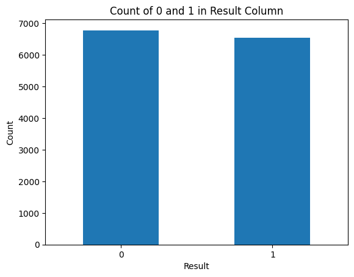

```python
result_counts = df['result'].value_counts()
result_counts.plot(kind='bar')
plt.xlabel('Result')
plt.ylabel('Count')
plt.title('Count of 0 and 1 in Result Column')
plt.xticks(rotation=0)
plt.show()
```

In this stage we display a histogram to show the distribution of age ranges for the fighters. We can visually see most of the distrubution is located around 23ish to 43ish age range. We want to determine the outliers for age

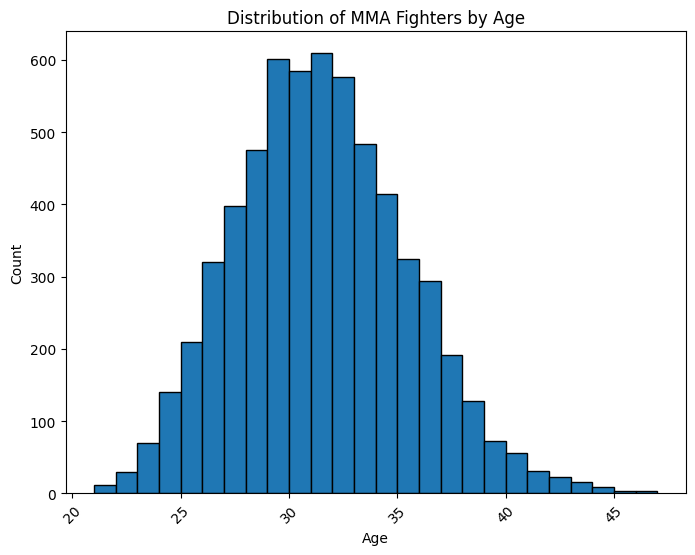

```python
plt.figure(figsize=(8, 6))
plt.hist(df_post['Age'], bins=range(min(df_post['Age']), max(df_post['Age']) + 2, 1), edgecolor='black')
plt.xlabel('Age')
plt.ylabel('Count')
plt.title('Distribution of MMA Fighters by Age')
plt.xticks(rotation=45)
plt.show()
```

Conventional wisdom states that older fighter's are usually worse off but in our case, older fighter may have over inflated stats due to facing weaker opponents. We can try to handle this by removing fighters older than 45 from our datasets, as they would be considered outliers either way.

```python
df_drop = df_drop[df_drop['Age']<45]
df_post = df_post[df_post['Age']<45]
df_pre = df_pre[df_pre['Age']<45]
```

Now taking a look at 'df_post' we can see that the cleaning has reduced the size of the data set considerably while still keeping an even balance of wins (1's) and losses (0's), in the new dataset. This means that whatever model we will train will remain well-balanced and should not be skewed to guess win's and losses more than it should. Now moving on to some more complex analyses.

While there are far too many (520) columns to do a correlation matrix with, we have handpicked some columns we believe can be powerful predictors to test the correlation matrix on.

```python
df_essence = df_post[[
    "result",
    "age_differential",
    "avg_head_strikes_landed_differential",
    "reach_differential",
    "height_differential",
    "takedowns_attempts_differential",
    "recent_avg_age_differential",
    "control_differential",
    "total_strikes_def_differential",
    "sig_strikes_landed_differential",
]]
```

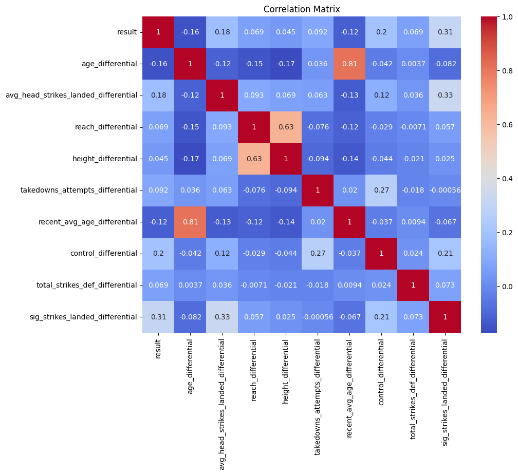

```python
corr_matrix = df_essence.corr()
plt.figure(figsize=(10, 8))
sns.heatmap(corr_matrix, annot=True, cmap='coolwarm')
plt.title('Correlation Matrix')
plt.show()
```

We choose to graph scattorplot where we graph against accuracy of Significant Strikes plotted against Significant Strike Defense'. We also color the the age as a bonus variable. Here we can notice that a positive linear relationship where the fighter has greater accuracy, the fighter will have greater defense. It shows that the skills of the fighter overall are correlated with eachother and as one skill improves the other skill will too

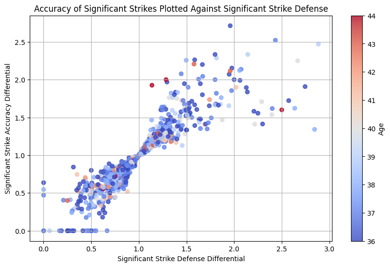

```python
df_filtered = df_post[df_post['sig_strikes_def_differential'] <df_post['sig_strikes_def_differential'].quantile(0.98)]
df_filtered = df_filtered[df_filtered['sig_strikes_accuracy_differential'] <df_filtered['sig_strikes_accuracy_differential'].quantile(0.98)]
df_filtered = df_filtered[df_filtered['Age'] > 35]
x = df_filtered['sig_strikes_def_differential']
y = df_filtered['sig_strikes_accuracy_differential']

plt.figure(figsize=(10, 6))
plt.scatter(x, y, c=df_filtered['Age'], cmap='coolwarm', alpha=0.8)
plt.xlabel('Significant Strike Defense Differential')
plt.ylabel('Significant Strike Accuracy Differential')
plt.title('Accuracy of Significant Strikes Plotted Against Significant Strike Defense')
plt.colorbar(label='Age')
plt.grid(True)
plt.show()
```

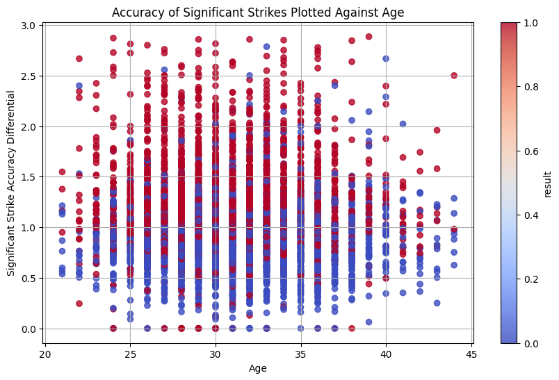

```python
df_filtered = df_post[df_post['sig_strikes_def_differential'] <df_post['sig_strikes_def_differential'].quantile(0.98)]

x = df_filtered['Age']
y = df_filtered['sig_strikes_def_differential']
plt.figure(figsize=(10, 6))
plt.scatter(x, y, c=df_filtered['result'], cmap='coolwarm', alpha=0.8)  # Adjust alpha value (0.3 in this example)
plt.xlabel('Age')
plt.ylabel('Significant Strike Accuracy Differential')
plt.title('Accuracy of Significant Strikes Plotted Against Age')
plt.colorbar(label='result')

plt.grid(True)
plt.show()
```

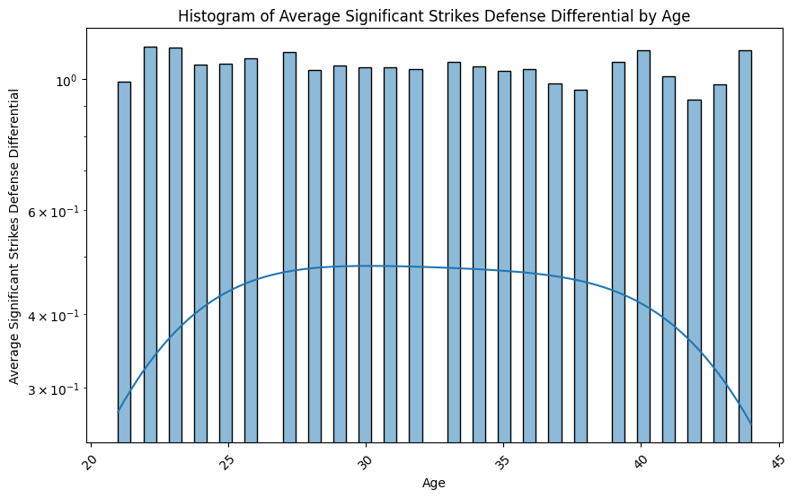

```python
age_groups = df_filtered.groupby('Age')['sig_strikes_def_differential'].mean().reset_index()

plt.figure(figsize=(10, 6))
sns.histplot(data=age_groups, x='Age', weights='sig_strikes_def_differential', kde=True, bins = 50)
plt.xlabel('Age')
plt.ylabel('Average Significant Strikes Defense Differential')
plt.title('Histogram of Average Significant Strikes Defense Differential by Age')
plt.yscale('log')
plt.xticks(rotation=45)
plt.show()
```

We assume here that outliers in terms of significant strike defense differential, specifcially outliers that appear above the rest of the box and whisker plot, are very good fighters. So we can see here the numbers of fighters that we consider very good decreases as age increases, and is greatest in the 25-36 range.

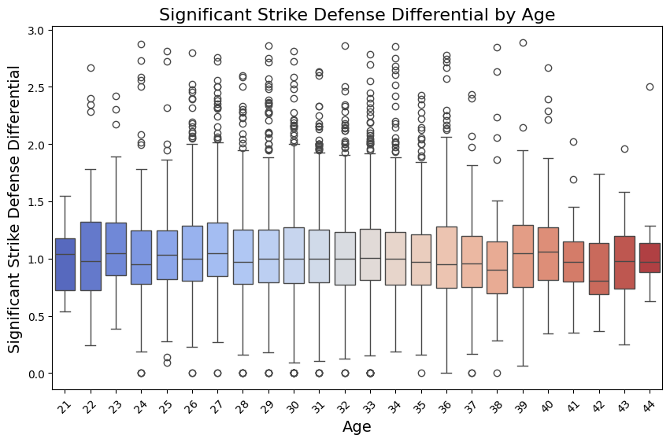

```python
df_filtered = df_post[(df_post['sig_strikes_def_differential'] < df_post['sig_strikes_def_differential'].quantile(0.98))]

fig, ax = plt.subplots(figsize=(10, 6))
sns.boxplot(x='Age', y='sig_strikes_def_differential', data=df_filtered, ax=ax, palette='coolwarm')
ax.set_xlabel('Age', fontsize=14)
ax.set_ylabel('Significant Strike Defense Differential', fontsize=14)
ax.set_title('Significant Strike Defense Differential by Age', fontsize=16)
plt.xticks(rotation=45)
plt.show()
```

### Scientific Method - Hypothesis Test For Reach Differential (1)

We want to test whether reach differential (differential stats are calculated by diving the two individual's technique stats), affects the outcome of the match.

Null Hypothesis: Reach differential has no impact on the outcome of the match.

Alternative Hypothesis: Reach differential has an effect on the outcome of the match.

We will use an significance level of 0.5

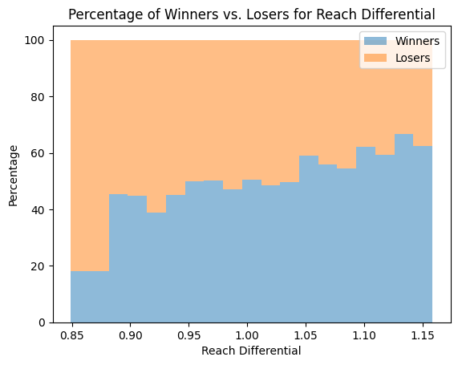

```python
df_w = df_drop[df_drop['result'] == 1]
df_l = df_drop[df_drop['result'] == 0]

bins = np.linspace(df_drop["reach_differential"].min(), df_drop["reach_differential"].max(), 20)

hist_w, _ = np.histogram(df_w["reach_differential"], bins=bins)
hist_l, _ = np.histogram(df_l["reach_differential"], bins=bins)

total_count = hist_w + hist_l

percent_winners = (hist_w / total_count) * 100
percent_losers = (hist_l / total_count) * 100

plt.bar(bins[:-1], percent_winners, width=np.diff(bins), alpha=0.5, label='Winners')
plt.bar(bins[:-1], percent_losers, width=np.diff(bins), alpha=0.5, label='Losers', bottom=percent_winners)

plt.xlabel('Reach Differential')
plt.ylabel('Percentage')
plt.title('Percentage of Winners vs. Losers for Reach Differential')
plt.legend()

plt.show()
```

### Scientific Method : Hypothesis Testing (Chi-Squared) For Name (2)

We want to see if which features are important in predicting result since that is our final goal

We first test a feature that we think think may have an affect which is the name of fighter and its correlation to result

Null Hypothesis: Name of the fighter has no effect on results

Alternatve Hypothesis: Name of the fighter has an effect on the results

We use chi squared to determine correlation

We set signifcance level to 0.05

```python
lst = df_drop['fighter'].value_counts().head(7).index.tolist()
lst
```

```
['Donald Cerrone',
 'Jim Miller',
 'Demian Maia',
 'Rafael Dos Anjos',
 'Diego Sanchez',
 'Dustin Poirier',
 'Jeremy Stephens']
```

```python
con = pd.crosstab(df_drop['fighter'], df_drop['result'])
```

```python
chi2, p, dof, expected = scipy.stats.chi2_contingency(con)
p
```

```
0.0004668659790882395
```

```python
df_drop_viz = df_drop[df['fighter'].isin(lst)]
```

```python
df_drop_viz.head()
```

|  | date | fight_url | event_url | result | fighter | opponent | division | stance | dob | method | ... | precomp_recent_avg_clinch_strikes_attempts_per_min | avg_ground_strikes_landed_per_min | precomp_avg_ground_strikes_landed_per_min | recent_avg_ground_strikes_landed_per_min | precomp_recent_avg_ground_strikes_landed_per_min | avg_ground_strikes_attempts_per_min | precomp_avg_ground_strikes_attempts_per_min | recent_avg_ground_strikes_attempts_per_min | precomp_recent_avg_ground_strikes_attempts_per_min | Age |
| --- | --- | --- | --- | --- | --- | --- | --- | --- | --- | --- | --- | --- | --- | --- | --- | --- | --- | --- | --- | --- | --- |
| 1295 | 2006-12-13 | http://ufcstats.com/fight-details/bc0155d267fb... | http://ufcstats.com/event-details/21b8a0f5c231... | 1 | Diego Sanchez | Joe Riggs | Welterweight | Southpaw | 1981-12-31 | KO/TKO | ... | 0.600000 | 2.557526 | 2.726174 | 1.282540 | 1.488889 | 4.041418 | 4.506844 | 1.482540 | 2.711111 | 24 |
| 1398 | 2007-04-07 | http://ufcstats.com/fight-details/fc4e42a55ba2... | http://ufcstats.com/event-details/c1684f00c626... | 0 | Diego Sanchez | Josh Koscheck | Welterweight | Southpaw | 1981-12-31 | U-DEC | ... | 0.488889 | 2.192165 | 2.557526 | 1.282540 | 1.282540 | 3.464072 | 4.041418 | 1.482540 | 1.482540 | 25 |
| 1576 | 2007-09-22 | http://ufcstats.com/fight-details/344e6898a381... | http://ufcstats.com/event-details/bad28b7b34f3... | 0 | Diego Sanchez | Jon Fitch | Welterweight | Southpaw | 1981-12-31 | S-DEC | ... | 0.422222 | 1.926478 | 2.192165 | 0.593651 | 1.282540 | 3.039397 | 3.464072 | 0.593651 | 1.482540 | 25 |
| 1713 | 2008-03-01 | http://ufcstats.com/fight-details/bcf49463525e... | http://ufcstats.com/event-details/598a58db87b8... | 1 | Diego Sanchez | David Bielkheden | Welterweight | Southpaw | 1981-12-31 | KO/TKO | ... | 0.155556 | 2.277795 | 1.926478 | 1.718335 | 0.593651 | 3.855985 | 3.039397 | 3.485120 | 0.593651 | 26 |
| 1835 | 2008-06-21 | http://ufcstats.com/fight-details/31c2d8648b06... | http://ufcstats.com/event-details/2299605af59f... | 1 | Diego Sanchez | Luigi Fioravanti | Welterweight | Southpaw | 1981-12-31 | KO/TKO | ... | 0.155556 | 2.149189 | 2.277795 | 2.048914 | 1.718335 | 3.640398 | 3.855985 | 4.051826 | 3.485120 | 26 |

5 rows × 530 columns

```python
import scipy
con = pd.crosstab(df_drop_viz['fighter'], df_drop_viz['result'])
```

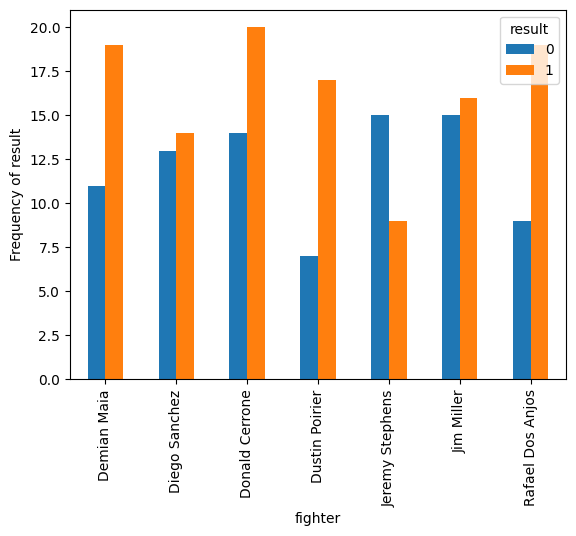

```python
a = con.plot(kind='bar')
a.set_ylabel('Frequency of result')
```

Since the p-value is well below our chosen alpha value, we can reject our null hypothesis, and say that who the fighter is has an effect on the result. This is also clearly visible on the plot of the seven most common fighters in our database. This demonstrates that the name of the fighter is an important feature when we build our model to determine the result.

### Scientific Method: Hypothesis Testing (Anova) For Age Range (3)

We want to identify the features which are important for figuring out how to get the results. We hypothesize that age range might be one of these features. To this end, we compare age range and results with ANOVA, to determine if there is any correlation

Null Hypothesis: There is no correlation between age range and result

Alternative Hypothesis: There is correlation between age range and result

Level of significance: We set our alpha value at .05

```python
def age_r(x):
    if x > 45:
        return "45-50"
    elif x > 40:
        return "40-45"
    elif x > 35:
        return "35-40"
    elif x > 30:
        return "30-35"
    elif x > 25:
        return "25-30"
    else:
        return "20-25"

df_drop["age_range"] = df_drop["Age"].apply(age_r)
```

```python
twtf = []
tfth = []
thtf = []
tfft = []
ftfv = []
fvff = []
for index, row in df_drop.iterrows():
    if row["age_range"] == '20-25':
        twtf.append(row["result"])
    elif row["age_range"] == '25-30':
        tfth.append(row["result"])
    elif row["age_range"] == '30-35':
        thtf.append(row["result"])
    elif row["age_range"] == '35-40':
        tfft.append(row["result"])
    elif row["age_range"] == '40-45':
        ftfv.append(row["result"])
    else:
        fvff.append(row["result"])
```

```python
import scipy
con = pd.crosstab(df_drop['age_range'], df_drop['result'])
print(con)
```

```
result        0     1
age_range
20-25       201   260
25-30      1108  1271
30-35      1273  1134
35-40       437   306
40-45        48    31
```

```python
con2 = pd.crosstab(df_drop['age_range'], df_drop['result'])
chi2, p, dof, expected = scipy.stats.chi2_contingency(con2)
p
```

```
9.333485226262541e-11
```

```python
f_stat, p = scipy.stats.f_oneway(twtf, tfth, thtf, tfft, ftfv)
print(p)
```

```
8.491836952180507e-11
```

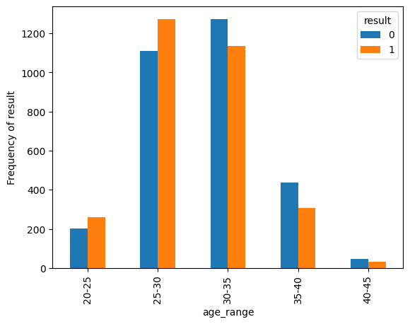

```python
import scipy
con = pd.crosstab(df_drop['age_range'], df_drop['result'])
a = con.plot(kind = 'bar')
a.set_ylabel('Frequency of result')
```

Based on the analysis conducted, it is evident that the alternate hypothesis can be supported due to the low p-value obtained from the statistical tests. The results indicate that there is sufficient evidence to conclude that there is a significant relationship or effect as hypothesized. Therefore, we reject the null hypothesis.

## 4. Primary Analysis

Now that we have finished loading, cleaning and exploring our data, we can finally start builiding a machine learning model for our dataset.

**We first want to compare the model performance between using KNN and then random forest for classification**  
**Let us first use all the dataset information from the fight match to predict (df_post)**. This includes both the prefight and the postfight data. Let us first do KNN

```python
X = df_post.drop('result', axis=1)
y = df_post['result']
X = StandardScaler().fit_transform(df_post.drop(['result'], axis=1))

X_train, X_test, y_train, y_test = train_test_split(X, y, test_size=0.2, random_state=42)

knn = KNeighborsClassifier(n_neighbors=150)

knn.fit(X_train, y_train)

y_pred = knn.predict(X_test)

print('Accuracy:', accuracy_score(y_test, y_pred))
print('Classification Report:\n', classification_report(y_test, y_pred))
```

```
Accuracy: 0.7191103789126854
Classification Report:
               precision    recall  f1-score   support

           0       0.66      0.89      0.76       593
           1       0.84      0.55      0.67       621

    accuracy                           0.72      1214
   macro avg       0.75      0.72      0.71      1214
weighted avg       0.75      0.72      0.71      1214
```

We visualize the confusion matrix next, seeing the numbers of false positives, false negatives, true positives, and true negatives. We can see that the number of false negatives is much higher than the number of false positives.

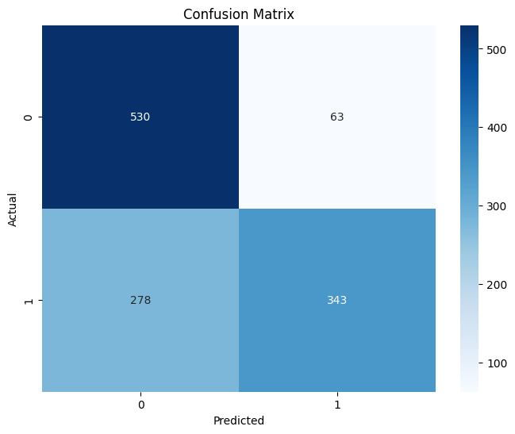

```python
y_pred = knn.predict(X_test)

cm = confusion_matrix(y_test, y_pred)

plt.figure(figsize=(8, 6))
sns.heatmap(cm, annot=True, cmap='Blues', fmt='g')
plt.xlabel('Predicted')
plt.ylabel('Actual')
plt.title('Confusion Matrix')
plt.show()
```

Now we attempt to utlize random forest on the entire fight (post fight) dataset to compare against KNN

```python
X_train, X_test, Y_train, Y_test = train_test_split(X, Y, test_size=0.2, random_state=42)
rf_model = RandomForestClassifier(n_estimators=200, random_state=42)
rf_model.fit(X_train, Y_train)
```

```
RandomForestClassifier(n_estimators=200, random_state=42)
```

```python
Y_pred = rf_model.predict(X_test)
print('Accuracy:', accuracy_score(Y_test, Y_pred))
print('Classification Report:\n', classification_report(Y_test, Y_pred))
```

```
Accuracy: 0.8311367380560132
Classification Report:
               precision    recall  f1-score   support

           0       0.82      0.83      0.83       593
           1       0.84      0.83      0.83       621

    accuracy                           0.83      1214
   macro avg       0.83      0.83      0.83      1214
weighted avg       0.83      0.83      0.83      1214
```

Let us model the most important features for the post fight dataset from the random forest model. We see some of the top predictors or factors are total strikes and head strikes landed differential (the difference between the fighter and the opponent) are the biggest factors.

```
                                  feature  importance
57       head_strikes_landed_differential    0.041795
55      total_strikes_landed_differential    0.040027
53        sig_strikes_landed_differential    0.034483
68   ground_strikes_attempts_differential    0.028031
67     ground_strikes_landed_differential    0.027728
..                                    ...         ...
6                               reversals    0.000150
516                       stance_Orthodox    0.000119
517                       stance_Southpaw    0.000073
518                         stance_Switch    0.000060
515                    stance_Open Stance    0.000000

[519 rows x 2 columns]
```

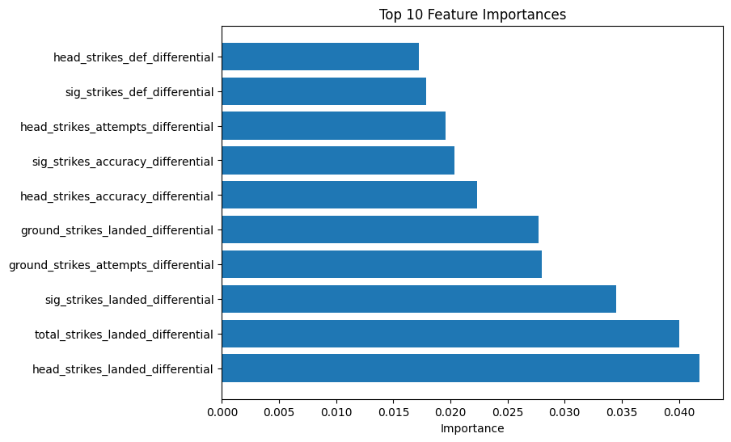

```python
importances = rf_model.feature_importances_
feature_importances = pd.DataFrame({'feature': df_post.drop(['result'], axis=1).columns, 'importance': importances})
feature_importances = feature_importances.sort_values('importance', ascending=False)

print(feature_importances)
top_10_features = feature_importances.head(10)

plt.figure(figsize=(8, 6))
plt.barh(range(len(top_10_features)), top_10_features['importance'], align='center')
plt.yticks(range(len(top_10_features)), top_10_features['feature'])
plt.xlabel('Importance')
plt.title('Top 10 Feature Importances')
plt.show()
```

Now we display the learning curve of the training process to get better insight on how the random forest model is performing. Notice how much better the model accuracy is performing as the training set data is larger. Notice after 2000 for the training data, the accuracy improves at smaller rate.

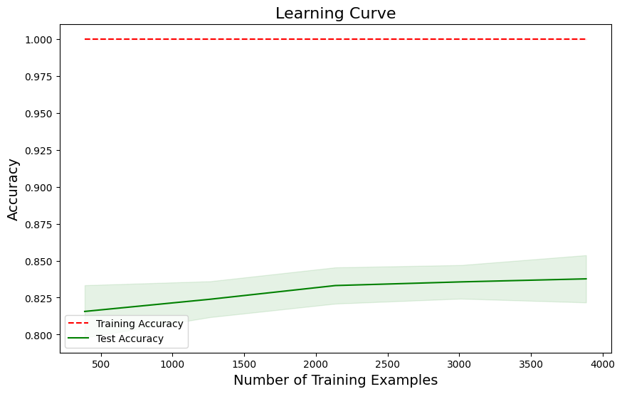

```python
train_sizes, train_scores, test_scores = learning_curve(
    rf_model, X_train, Y_train, cv=5, scoring='accuracy', n_jobs=-1)
train_mean = np.mean(train_scores, axis=1)
train_std = np.std(train_scores, axis=1)
test_mean = np.mean(test_scores, axis=1)
test_std = np.std(test_scores, axis=1)

plt.figure(figsize=(10, 6))
plt.plot(train_sizes, train_mean, '--', color='r', label='Training Accuracy')
plt.plot(train_sizes, test_mean, '-', color='g', label='Test Accuracy')
plt.fill_between(train_sizes, train_mean - train_std, train_mean + train_std, alpha=0.1, color='r')
plt.fill_between(train_sizes, test_mean - test_std, test_mean + test_std, alpha=0.1, color='g')
plt.xlabel('Number of Training Examples', fontsize=14)
plt.ylabel('Accuracy', fontsize=14)
plt.title('Learning Curve', fontsize=16)
plt.legend(loc='best')
plt.show()
```

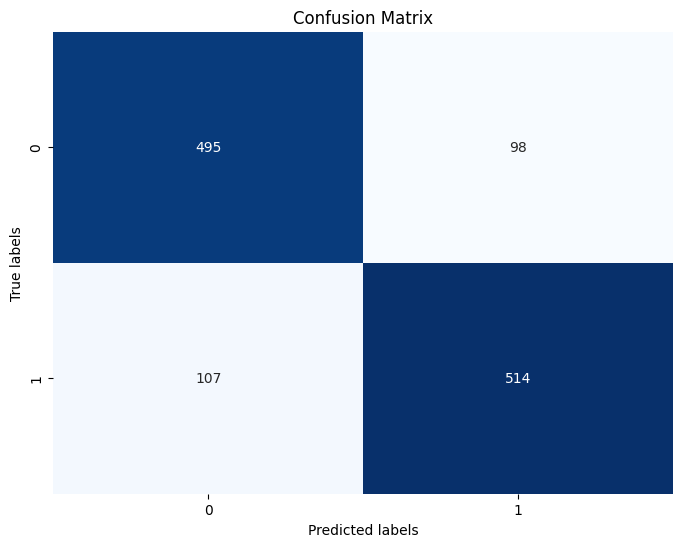

```python
conf_matrix = confusion_matrix(Y_test, Y_pred)
plt.figure(figsize=(8, 6))
sns.heatmap(conf_matrix, annot=True, fmt='d', cmap='Blues', cbar=False)
plt.xlabel('Predicted labels')
plt.ylabel('True labels')
plt.title('Confusion Matrix')
plt.show()
```

We move onto now trying to predict match result with ONLY pre fight statistics. This will be more representative of an actual case of predicting a match result. Since we compared both KNN and random forest in the previous and random forest seemed to perform better, we will try to work with only random forest for this case

```python
X2 = StandardScaler().fit_transform(df_pre.drop(['result'], axis=1))
Y2 = df_pre['result']
X_train2, X_test2, Y_train2, Y_test2 = train_test_split(X2, Y2, test_size=0.2, random_state=42)
rf_model_pre = RandomForestClassifier(n_estimators=200, random_state=42)
rf_model_pre.fit(X_train2, Y_train2)
```

```
RandomForestClassifier(n_estimators=200, random_state=42)
```

Noitce accuracy, precision, and recall have descreased now that we are limiting the number of statistics we can utilize

```python
Y_pred2 = rf_model_pre.predict(X_test2)
print('Accuracy:', accuracy_score(Y_test2, Y_pred2))
print('Classification Report:\n', classification_report(Y_test2, Y_pred2))
```

```
Accuracy: 0.5609555189456342
Classification Report:
               precision    recall  f1-score   support

           0       0.55      0.59      0.57       593
           1       0.58      0.54      0.56       621

    accuracy                           0.56      1214
   macro avg       0.56      0.56      0.56      1214
weighted avg       0.56      0.56      0.56      1214
```

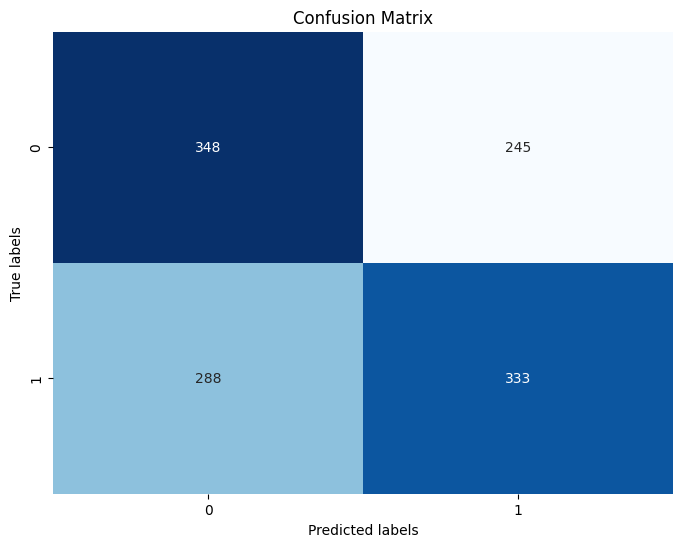

```python
conf_matrix = confusion_matrix(Y_test2, Y_pred2)

plt.figure(figsize=(8, 6))
sns.heatmap(conf_matrix, annot=True, fmt='d', cmap='Blues', cbar=False)
plt.xlabel('Predicted labels')
plt.ylabel('True labels')
plt.title('Confusion Matrix')
plt.show()
```

Now we graph and display the feature importances of the new model. With only pre fight stats we can notice that biggest factors is related to age with age differential (difference of ages between fighter and opponent).

```
                                              feature  importance
7                                    age_differential    0.060305
8                 precomp_recent_avg_age_differential    0.050740
11  precomp_recent_avg_sig_strikes_attempts_differ...    0.050228
12  precomp_recent_avg_total_strikes_def_differential    0.049916
10            precomp_recent_avg_control_differential    0.047930
5                                  reach_differential    0.046749
16                         precomp_recent_avg_control    0.045414
6                                 height_differential    0.042519
21            precomp_recent_avg_total_strikes_landed    0.040968
22          precomp_recent_avg_total_strikes_attempts    0.039817
30       precomp_recent_avg_distance_strikes_attempts    0.039231
20            precomp_recent_avg_sig_strikes_attempts    0.039000
29         precomp_recent_avg_distance_strikes_landed    0.038842
24           precomp_recent_avg_head_strikes_attempts    0.038335
```

[output cut: 17 more lines]

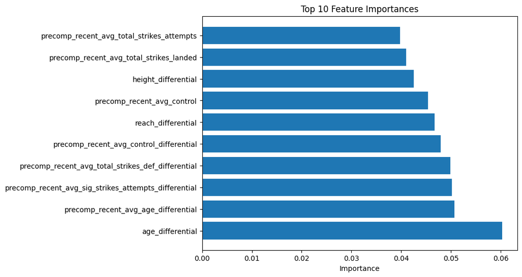

```python
importances = rf_model_pre.feature_importances_
feature_importances = pd.DataFrame({'feature': df_pre.drop(['result'], axis=1).columns, 'importance': importances})
feature_importances = feature_importances.sort_values('importance', ascending=False)

print(feature_importances)
top_10_features = feature_importances.head(10)

plt.figure(figsize=(8, 6))
plt.barh(range(len(top_10_features)), top_10_features['importance'], align='center')
plt.yticks(range(len(top_10_features)), top_10_features['feature'])
plt.xlabel('Importance')
plt.title('Top 10 Feature Importances')
plt.show()
```

The above graph demonstrates the importances of each feature to the random forest model. From it, we can see that while age differential is the most important feature, the features don't very by that much in terms of importance

## 5. Visualization

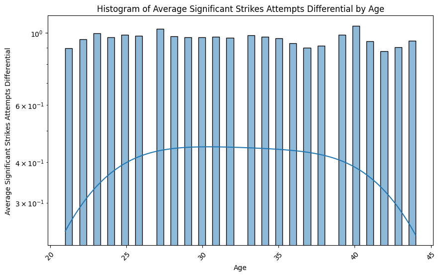

```python
age_groups = df_filtered.groupby('Age')['sig_strikes_accuracy_differential'].mean().reset_index()
plt.figure(figsize=(10, 6))
sns.histplot(data=age_groups, x='Age', weights='sig_strikes_accuracy_differential', kde=True, bins=50)
plt.xlabel('Age')
plt.ylabel('Average Significant Strikes Attempts Differential')
plt.title('Histogram of Average Significant Strikes Attempts Differential by Age')
plt.yscale('log')
plt.xticks(rotation=45)
plt.show()
```

Here we are plotting the average age differential vs. the recent average significant strikes landed. This is basically the average age differential and strikes landed for the past fights the fighter has participated in. We also color the points by their actual age. What we see that is that older fighter are typically having a higher age differntial with their opponent meaning they are more often then not fighting younger opponents. Also notice the bell curve like shape formed by the points. When the age differential is closer to 1 and the ages are around 27-33, there are higher significant striked being landed by the fighter. With higher strikes landed, the more likely the fighter is to win a fight. This connects to our insight from the primary analysis that age differential does play a big factor to determing the wins and losses.

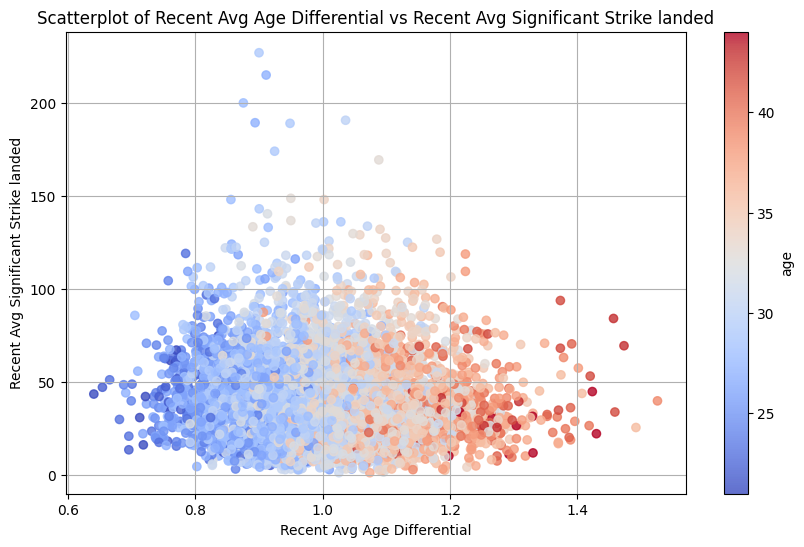

```python
y = df_pre['precomp_recent_avg_sig_strikes_landed']
x = df_pre['precomp_recent_avg_age_differential']
plt.figure(figsize=(10, 6))
plt.scatter(x, y, c=df_pre['Age'], cmap='coolwarm', alpha=0.8)  # Adjust alpha value (0.3 in this example)
plt.xlabel('Recent Avg Age Differential')
plt.ylabel('Recent Avg Significant Strike landed')
plt.title('Scatterplot of Recent Avg Age Differential vs Recent Avg Significant Strike landed')
plt.colorbar(label='age')
plt.grid(True)
plt.show()
```

## 6. Insights And Conclusion

Overall, the conclusions from our finding is that it is difficult to predict the results of a match, based on just the pre-fight data, as our overall accuracy was .56 with the Random Forest model, which is considered to be one of the best models with regard to classification. The features that we found were best for the prediction was the age differential between the fighter and the opponent, or how different the ages of a fighter and his opponent was. We found that this also correlated with how many strikes a fighter landed during their fight, helping us figure out why age differential was so important in determining the outcome of a match.